# Keras 101 : Building a Simple Classification Neural Network with Keras

To begin we need to do some package installations. We'll be using keras to build our neural network (conda install keras), tensorflow as the backend for keras (conda install tensorflow), and scikit-learn to generate some training data (conda install scikit-learn). We will also be requiring numpy and matplotlib.

To start our python script we need to import all the necessary packages. Although we had to install the tensorflow package it is not necessary to import it.

```python
import keras
from sklearn.datasets import make_circles
import matplotlib.pyplot as plt
import numpy as np
```

Next we need to generate some data that we wish to classify. The make_circles function imported from sklearn.datasets returns all the data we require, this consits of two arrays wrapped in a list (dataset).

The first item in the returned list consists of x1 and x2 features (these are our input features), the second item consists of an array of labels for each pair of x1 and x2 features (these are our target labels or ground truths) these labels classify each pair of x1 and x2 features as a 1 or a 0.

The aim of our network will be to produce a decicion boundary that seperates these two classes of data.

```python
dataset = make_circles(n_samples=500,noise=0.1,factor=0.5, random_state=1)

features = dataset[0]
print("Features:",features[:10])
labels = dataset[1]
print("Labels:",labels[:10])
```

```
Features: [[ 0.19930804  0.56902277]
 [-0.15616416  0.31072201]
 [ 0.42223279  0.9327946 ]
 [-0.22081431  0.87992814]
 [ 0.50235893 -0.36354974]
 [ 0.47181124 -0.03155686]
 [-0.017868    0.51151136]
 [ 0.76001051  0.69706718]
 [ 1.07838053 -0.22967663]
 [-0.5923828   0.76194607]]
Labels: [1 1 0 0 1 1 1 0 0 0]
```

We can plot our data set and begin to get an idea of the how the two classes are distributed in relation to the features x1 and x2.

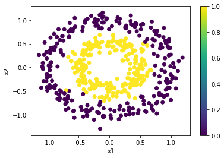

```python
plt.scatter(features[:,0],features[:,1],c=labels)
plt.xlabel("x1")
plt.ylabel("x2")
plt.colorbar()
plt.show()
```

We next need to generate some variables that describe some infromation about our dataset. Specifically the length of our data set, the max and min values for both x1 and x2 features.

```python
data_len = features.shape[0]

x1_min = np.amin(features[:,0])
x1_max = np.amax(features[:,0])
x2_min = np.amin(features[:,1])
x2_max = np.amax(features[:,1])

print(x1_min,x1_max,x2_min,x2_max)
```

```
-1.1347888750834922 1.1832537855699603 -1.2961020431514352 1.1548947642414218
```

```python
X_train = features[:int(data_len*0.7)]
X_test = features[int(data_len*0.3):]
y_train = labels[:int(data_len*0.7)]
y_test = labels[int(data_len*0.3):]
```

We can now begin to build our neural network model. At this point we need to start thinking about how we are going to train our model. To train this model we are going to feed each pair of features (x1,x2) into the network where it will output a classification between 1 and 0 for that single pair of features. This is repeated for every pair in the data set.

The training procedure will compare the network output with the corresponding label (groundtruth) and calulate a loss for that feature pair, the necessary adjustments to the network will then be made via the backpropergation and an optimzation algorithm specified later.

This network will therefore conist of an input layer of 2 features (input_dim) and an output layer of 1 neuron.

Between the input and output layers we will place a single hidden layer 3 neurons wide. The choice of a single hidden layer is related to the simplicity of the decision boundary required due to the symmetry of the data set around 0,0 (I think...).

The network will aim to output either a 1 or 0, as such our choice of activation function is the sigmoid for all neurons in the network.

To build the model we begin by building a list of densly connected layers using the keras.layers.Dense(Number of neurons, input_dim = number of features input into the first layer of network, activation = activation function) componant. We append them to our list in the order in which they will appear in the network. The shape of our input is specified by the input_dim parameter in the first layer.

we can then pass this layers list into the keras.Sequential() constructor.

```python
layers = []
layers.append(keras.layers.Dense(3,input_dim = 2, activation="sigmoid"))
layers.append(keras.layers.Dense(1, activation="sigmoid"))
model = keras.Sequential(layers)
```

Once built we can compile our model and assign our choice of optimizer, loss function and the metrics we wish to output inorder to monitor the progress of our training. Here we will be using the keras implimentaion of the adam optimizer for which we specify a learning rate (lr). The loss of our model will be calculated using the 'binary_crossentropy' function as we only have one output neuron (or a binary choice).

```python
model.compile(optimizer=keras.optimizers.Adam(lr=0.1), loss='binary_crossentropy', metrics=['binary_accuracy', 'categorical_accuracy'])
```

We are now ready to fit our model, here we need to pass our training features (X_train) and trianing labels (y_train) as well as our testing features (X_test) and testing labels (y_test) for cross validation during the training. We also specify the batch size (for us the entire training set will be passed through the network before adjusting the weights of the network) and how many epochs we wish to train for. We also specify how much information we wish to display during training with verbose=1 so that we can monitor the training as it runs.

The model.fit() function also returns a history of useful metrics such as loss and crossvalidation loss that we can use to determine how well our network is training and our choice of hyperparameters such as learning rate.

```python
history = model.fit(X_train, y_train,validation_data=(X_test,y_test), batch_size=X_train.shape[0],epochs=1000, verbose=1)
```

[output not shown]

We can then plot the loss and cross validation loss (based on training and test data respectively) in order to determine hwo well our network has trained as well as look for signs of overfitting and underfitting.

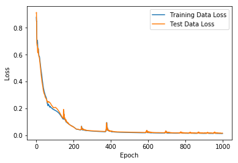

```python
loss = history.history['loss']
val_loss = history.history['val_loss']
epoch = np.arange(0, len(loss))

plt.plot(epoch,loss, label='Training Data Loss')
plt.plot(epoch,val_loss,label='Test Data Loss')
plt.xlabel('Epoch')
plt.ylabel('Loss')
plt.legend()
plt.show()
```

We now want to plot our decicion boundary for our trainined model. we do this by building a mesh the size of our x1 and x2 limits.

```python
xx, yy = np.meshgrid(np.arange(x1_min,x1_max,0.01),np.arange(x2_min,x2_max,0.01))
```

We can pass this mesh into the model.predict() function that returns a classification prediction for every point in the mesh. We can then plot this in order to visulize our trained decision boundary.

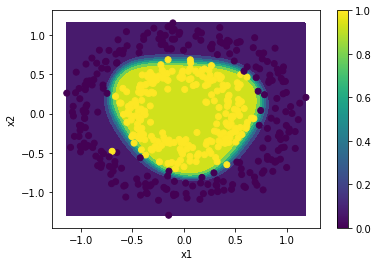

```python
z = model.predict(np.c_[xx.ravel(),yy.ravel()])
z = z.reshape(xx.shape)

plt.contourf(xx,yy,z)
plt.scatter(features[:,0],features[:,1],c=labels)
plt.xlabel('x1')
plt.ylabel('x2')
plt.colorbar()
plt.show()
```